# Differences-in-Differences

ChatGPT 4o

2025-01-21

## 1 起源

双重差分（Differences-in-Differences, DiD）方法起源于社会科学研究，最早用于评估政策的因果效应，尤其是在政策干预或自然实验无法进行随机控制的情况下。DiD在20世纪中叶逐渐发展起来，并在20世纪末期被广泛应用于经济学、公共政策和医学等领域。该方法的核心思想是通过比较处理组和对照组在干预前后的差异来估计干预效果。

## 2 原理

DiD方法的基本原理是通过比较处理组和对照组在干预前后的变化差异，来推断干预的因果效应。其关键假设是**平行趋势假设**，即在没有干预的情况下，处理组和对照组的趋势是相同的。为了验证平行趋势假设，可以在干预前的数据中比较处理组和对照组的变化趋势。如果在干预前两组的趋势一致，则平行趋势假设成立。具体来说，DiD估计的步骤包括：

1. **定义处理组和对照组**：处理组是受到政策干预或实验处理的群体，对照组是未受到干预的群体。
2. **计算差异**：在干预前和干预后，分别计算处理组和对照组的结果变量差异。
3. **计算双重差异**：用处理组的差异减去对照组的差异，得到干预的因果效应。

DiD模型的数学表达式为：
$$Y_{it} = \alpha + \beta D_i + \gamma T_t + \delta (D_i \times T_t) +
\epsilon_{it}$$
其中： - $Y_{it}$ 表示个体$i$在时间$t$的结果变量； - $D_i$ 是处理组指示变量（1表示处理组，0表示对照组）； - $T_t$ 是时间指示变量（1表示干预后，0表示干预前）； - $D_i \times T_t$ 是交互项，用于捕捉处理组在干预后的变化； - $\delta$ 为DiD估计量，表示干预的因果效应。

## 3 适用范围

DiD方法适用于以下情况：

- **政策评估**：用于评估政策干预的效果，例如新法规、税收政策、社会福利计划等。
- **自然实验**：在无法进行随机控制的自然实验中，DiD可用于分析干预的效果。
- **长期数据**：适用于具有干预前后观察数据的纵向或面板数据。
- **处理组和对照组**：必须有处理组和对照组，并且在干预前需要遵循平行趋势假设。

## 4 应用情境

DiD方法在多个领域中有广泛的应用，例如：

- **经济学**：用于评估政策变化对就业率、收入水平等经济指标的影响。
- **公共政策**：用于评估新法规或项目对社会福利的影响，例如最低工资法对劳动市场的影响。
- **医学和公共卫生**：用于评估健康干预（如疫苗接种计划）对健康结果的影响。
- **教育学**：用于评估教育政策（如课时改革、教学方法变更）对学生成绩的影响。

## 5 优缺点

### 优点

- **减少混杂偏倚**：通过对比处理组和对照组的差异，DiD能够有效减少时间不变的混杂偏倚。
- **适用于自然实验**：DiD无需随机分配，适用于观察性数据和自然实验。
- **简单易于实现**：DiD模型易于理解和实现，且在政策评估中非常有效。

### 缺点

- **依赖平行趋势假设**：DiD的关键假设是处理组和对照组在干预前具有相同的趋势，违反该假设会导致估计偏倚。
- **无法控制时间变化的异质性**：如果处理组和对照组在干预期间有不同的时间变化，DiD可能会得到错误的结果。
- **受外部因素影响**：如果在干预期间有其他外部因素影响处理组或对照组，DiD的估计可能会受到干扰。

## 6 在R中的实现及结果解释

在R中，可以使用`lm()`函数来进行DiD分析，以下是一个DiD分析的示例：

```r
# 加载必要的包
library(ggplot2)

# 示例数据：生成假设的处理组和对照组数据
set.seed(123)
data <- data.frame(
  id = rep(1:100, each = 2),
  time = rep(c("pre", "post"), times = 100),
  group = rep(c("control", "treatment"), each = 100),
  outcome = c(rnorm(100, mean = 50, sd = 5), rnorm(100, mean = 52, sd = 5))
)
```

### 平行趋势假设检验

在进行DiD分析之前，我们需要验证平行趋势假设。可以通过在干预前的数据中比较处理组和对照组的趋势来验证。

```r
# 仅使用干预前的数据进行趋势检验
pre_data <- subset(data, time == "pre")
model_pre <- lm(outcome ~ group, data = pre_data)
summary(model_pre)
```

```
##
## Call:
## lm(formula = outcome ~ group, data = pre_data)
##
## Residuals:
##     Min      1Q  Median      3Q     Max
## -9.7718 -3.2421  0.0804  3.3189 10.9950
##
## Coefficients:
##                Estimate Std. Error t value Pr(>|t|)
## (Intercept)     50.5525     0.6349  79.624   <2e-16 ***
## grouptreatment   0.9531     0.8979   1.062    0.291
## ---
## Signif. codes:  0 '***' 0.001 '**' 0.01 '*' 0.05 '.' 0.1 ' ' 1
##
## Residual standard error: 4.489 on 98 degrees of freedom
## Multiple R-squared:  0.01137,    Adjusted R-squared:  0.001279
## F-statistic: 1.127 on 1 and 98 DF,  p-value: 0.2911
```

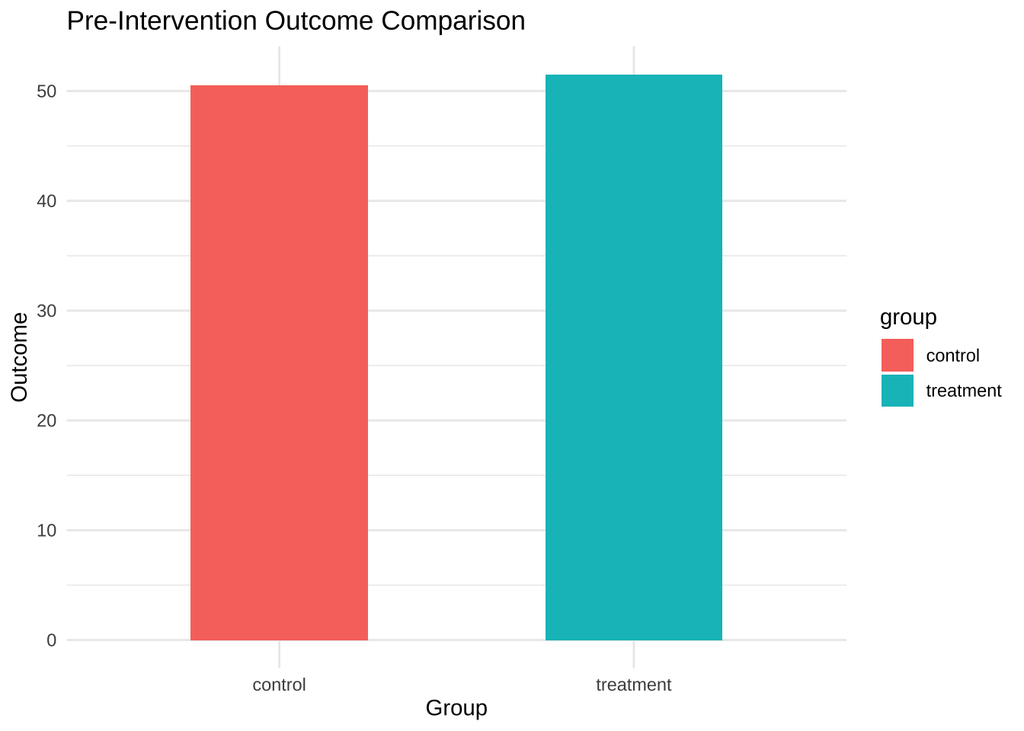

```r
# 可视化干预前处理组和对照组的结果变化
ggplot(pre_data, aes(x = group, y = outcome, fill = group)) +
  stat_summary(fun = mean, geom = "bar", position = position_dodge(), width = 0.5) +
  labs(title = "Pre-Intervention Outcome Comparison", x = "Group", y = "Outcome") +
  theme_minimal()
```

如果在干预前处理组和对照组之间没有显著差异，则平行趋势假设可能成立，可以继续进行DiD分析。

```r
# 创建处理组和时间指示变量
data$treat <- ifelse(data$group == "treatment", 1, 0)
data$post <- ifelse(data$time == "post", 1, 0)

# 进行DiD回归分析
data$interaction <- data$treat * data$post
model <- lm(outcome ~ treat + post + interaction, data = data)
summary(model)
```

```
##
## Call:
## lm(formula = outcome ~ treat + post + interaction, data = data)
##
## Residuals:
##      Min       1Q   Median       3Q      Max
## -11.8974  -3.2421  -0.4496   2.9854  16.7863
##
## Coefficients:
##             Estimate Std. Error t value Pr(>|t|)
## (Intercept)  50.5525     0.6682  75.657   <2e-16 ***
## treat         0.9531     0.9449   1.009    0.314
## post         -0.2009     0.9449  -0.213    0.832
## interaction   0.1143     1.3364   0.086    0.932
## ---
## Signif. codes:  0 '***' 0.001 '**' 0.01 '*' 0.05 '.' 0.1 ' ' 1
##
## Residual standard error: 4.725 on 196 degrees of freedom
## Multiple R-squared:  0.0118, Adjusted R-squared:  -0.00333
## F-statistic: 0.7798 on 3 and 196 DF,  p-value: 0.5065
```

```r
str(model)
```

[output not shown]

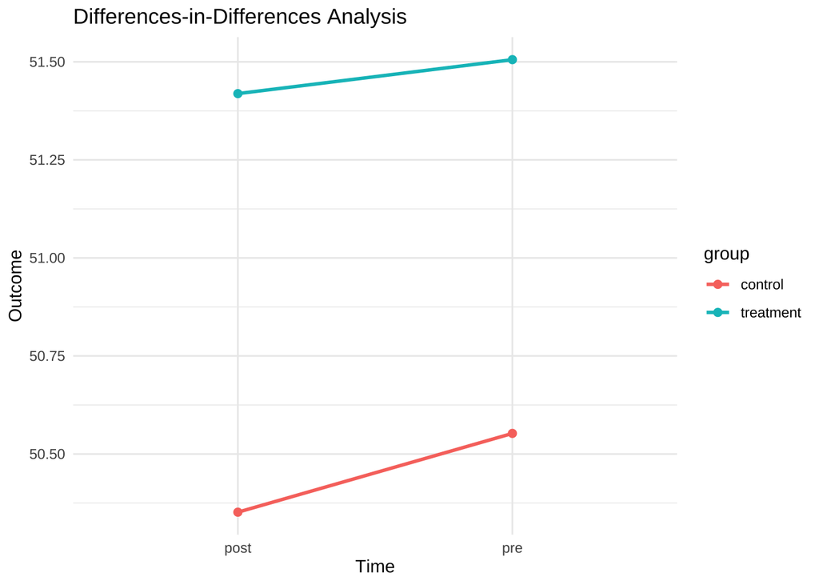

```r
# 可视化：绘制处理组和对照组在干预前后的结果变化
ggplot(data, aes(x = time, y = outcome, color = group, group = group)) +
  stat_summary(fun = mean, geom = "line", size = 1) +
  stat_summary(fun = mean, geom = "point", size = 2) +
  labs(title = "Differences-in-Differences Analysis", x = "Time", y = "Outcome") +
  theme_minimal()
```

### 结果解释

- **平行趋势假设检验结果**：通过在干预前的数据进行回归分析，检验处理组和对照组在干预前的差异。如果系数不显著，则表明两组具有相似的趋势，平行趋势假设成立。
- **回归结果摘要**：通过`lm()`函数进行DiD分析，结果中的交互项（`interaction`）的系数即为干预效果的估计值。如果交互项的系数显著，则表明干预对处理组有显著影响。
- **可视化结果**：通过绘制处理组和对照组在干预前后的平均结果变化，可以直观展示干预的效果。处理组和对照组在干预前后的变化差异反映了干预的效果。

### 结果的可视化

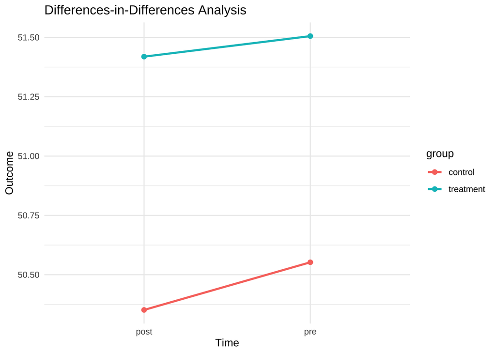

```r
# 使用ggplot2包绘制处理组和对照组在干预前后的变化趋势
ggplot(data, aes(x = time, y = outcome, color = group, group = group)) +
  stat_summary(fun = mean, geom = "line", size = 1) +
  stat_summary(fun = mean, geom = "point", size = 2) +
  labs(title = "Differences-in-Differences Analysis", x = "Time", y = "Outcome") +
  theme_minimal()
```

## 7 小结

- 双重差分（DiD）方法是一种用于评估政策干预或实验处理效果的因果推断方法，适用于观察性数据和自然实验。
- DiD通过比较处理组和对照组在干预前后的差异，减少时间不变的混杂偏倚。
- 其优点在于简单易行且适用于自然实验，但需要平行趋势假设成立，且容易受到外部因素影响。
- 可以通过R中的`lm()`函数进行DiD分析，并结合可视化工具展示处理组和对照组在干预前后的变化趋势。